# Applying Yourself

Beau B. Bruce

## Exercise

### The `apply` family

R has a group of functions that all work in a similar fashion. Each of these functions *takes a function as an argument* and applies that function to each of the elements of one of its other arguments.  
These functions can replace most `for`-loops in R and they are faster too.  
The model function for this family of functions that takes a function as an argument and applies it to another one of its arguments is: `apply`.  
(Programmers are not that creative with names - nor should they be!)

Not only are `apply` family functions generally faster than loops, but they are also more “R-like.” That is to say, when you think in terms of these functions you are thinking more like an R programmer. Just like different human languages have different figures of speech, idioms, and modes of thinking that characterize them, so do computer languages.

As we have discussed previously, R lends itself to functional types of programming idioms, one of which is called mapping. Mapping means taking a function and “mapping” it or “applying” it to every sub-element of vector, list, or array. So the `apply` family is a very “functional” programming idiom.

So, let’s get started with the `apply` function. The `apply` function works on the rows or columns of an `data.frame` or `array`. We have not met an `array` before but they are essentially a `vector` that has 2 or more dimensions (e.g., a table has two dimensions) of all the same **atomic** data type.  
We will create one that contains 10,000 coin flip experiments using 100 flips in each experiment.  
The function `rbinom` generates random binomially distributed data.

```r
# generates 100 fair coin flips
rbinom(100, 1, 0.5)
```

```
##   [1] 0 1 1 0 0 1 1 0 1 0 1 0 0 0 0 0 0 1 1 1 0 1 1 1 0 0 0 1 1 0 1 0 1 0 1
##  [36] 0 1 1 1 0 0 1 0 1 0 1 0 0 0 0 0 1 0 1 1 1 1 0 0 1 0 0 1 1 0 1 0 1 1 0
##  [71] 1 0 0 0 1 1 0 0 0 1 1 1 0 0 0 1 1 1 0 0 0 1 0 1 0 0 0 0 1 1
```

```r
# do it 10,000 times!
experiments <- replicate(10000, rbinom(100, 1, 0.5))
# first 10 rows and first 10 columns
experiments[1:10, 1:10]
```

```
##       [,1] [,2] [,3] [,4] [,5] [,6] [,7] [,8] [,9] [,10]
##  [1,]    0    1    0    1    0    1    0    1    1     0
##  [2,]    0    1    1    0    1    0    1    0    1     0
##  [3,]    0    1    0    0    1    1    0    1    0     0
##  [4,]    0    1    1    0    1    0    0    1    1     0
##  [5,]    1    0    0    0    1    1    0    0    1     0
##  [6,]    0    1    1    0    0    1    0    0    1     0
##  [7,]    0    0    1    1    0    1    1    1    0     0
##  [8,]    1    0    1    1    1    0    1    0    0     0
##  [9,]    1    1    1    0    1    0    0    0    1     1
## [10,]    1    1    0    0    0    0    0    0    0     0
```

```r
# what size is it?
NROW(experiments)
```

```
## [1] 100
```

```r
NCOL(experiments)
```

```
## [1] 10000
```

```r
dim(experiments)
```

```
## [1]   100 10000
```

So we have 10,000 experiments of 100 coin flips each. Each expermient is in one column (because there are 100 rows). If we wanted to plot a histogram of how many heads were flipped (calling 1 as heads and 0 as tails) then we could use the apply function to add each column up before calling `hist`:

```r
# the 2 represents the columns (remember they come "second" when
# talking about rows vs. columns); you would use 1 instead if you
# wanted to apply the function to the rows
heads <- apply(experiments, 2, sum)
length(heads)
```

```
## [1] 10000
```

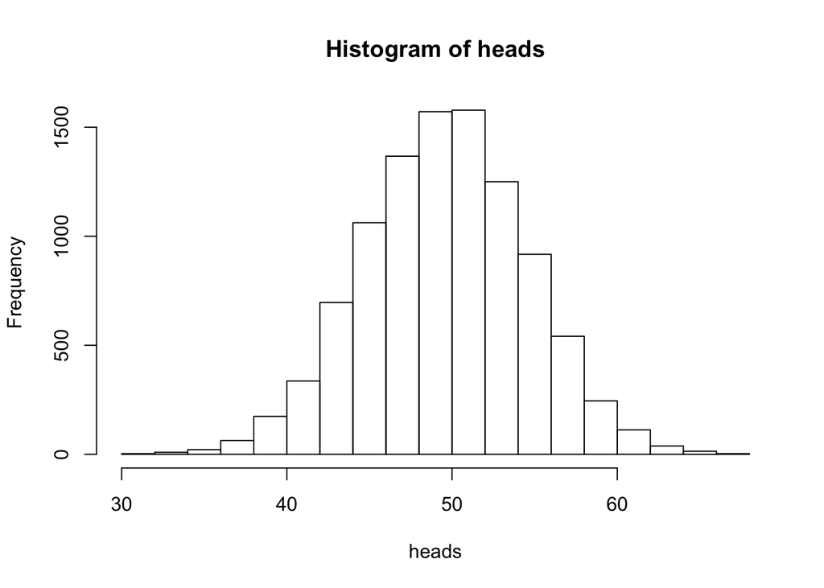

```r
hist(heads)
```

```r
mean(heads)
```

```
## [1] 50.0694
```

```r
var(heads)
```

```
## [1] 24.39742
```

### `lapply`

You probably recall from your basic statistics class that as the sample size increases our confidence in the mean increases. That means that the standard deviation / variance around the estimate of the mean decreases. Let’s test that in R. We could do the following, but it is a lot of typing to do almost the same thing:

```r
sd(replicate(1000, mean(rnorm(10,   100, 25)))) # 1000 experiments of n=10
```

```
## [1] 7.614028
```

```r
sd(replicate(1000, mean(rnorm(100,  100, 25)))) # 1000 experiments of n=100
```

```
## [1] 2.472707
```

```r
sd(replicate(1000, mean(rnorm(1000, 100, 25)))) # 1000 experiments of n=1000
```

```
## [1] 0.7853781
```

What if we converted the second part of the experession to a function like this?

```r
rsd <- function(n) sd(replicate(1000, mean(rnorm(n, 100, 25))))
```

Then, we could use the `lapply` function to complete these three lines of code in one:

```r
lapply(c(10, 100, 1000), rsd)
```

```
## [[1]]
## [1] 7.719444
##
## [[2]]
## [1] 2.504548
##
## [[3]]
## [1] 0.7926931
```

```r
lapply(c(10, 100, 1000), function(n) sd(replicate(1000, mean(rnorm(n, 100, 25)))))
```

```
## [[1]]
## [1] 7.835046
##
## [[2]]
## [1] 2.525144
##
## [[3]]
## [1] 0.7692873
```

That way you do not have to name the other function. It is your call when you name the function and use a lambda function.  
Most advanced programmers would do the latter in this case because it is short enough to comprehend easily, but either is absolutely acceptable.

Now, let’s return not only the variance but the mean. Maybe here the function is complicated enough that it is worth naming separately for clarity:

```r
rmv <- function(n) {
  r <- replicate(1000, mean(rnorm(n, 100, 25)))
  list(mean = mean(r), var = var(r))
}
lapply(c(10, 100, 1000), rmv)
```

```
## [[1]]
## [[1]]$mean
## [1] 99.71082
##
## [[1]]$var
## [1] 66.57651
##
##
## [[2]]
## [[2]]$mean
## [1] 100.021
##
## [[2]]$var
## [1] 6.524178
##
##
## [[3]]
## [[3]]$mean
## [1] 100.0552
##
## [[3]]$var
## [1] 0.5938446
```

Even more compact - and adding one more power of 10?

```r
lapply(10^(1:4), rmv)
```

```
## [[1]]
## [[1]]$mean
## [1] 99.98944
##
## [[1]]$var
## [1] 62.45481
##
##
## [[2]]
## [[2]]$mean
## [1] 99.90296
##
## [[2]]$var
## [1] 6.310107
##
##
## [[3]]
## [[3]]$mean
## [1] 99.99665
##
## [[3]]$var
## [1] 0.6537585
##
##
## [[4]]
## [[4]]$mean
## [1] 99.9995
##
## [[4]]$var
## [1] 0.06415171
```

This is less error prone, requires less typing, and is much more clear than cutting and pasting a lot of code.

When you return a single value you can use `sapply` to return a `vector` instead of a `list`:

```r
sapply(10^(1:3), rsd)
```

```
## [1] 7.9117228 2.4662771 0.7627908
```

or an `array` when you return more than one:

```r
sapply(10^(1:3), rmv)
```

```
##      [,1]     [,2]     [,3]
## mean 99.81276 100.0052 99.98096
## var  59.99898 5.956754 0.6194425
```

### Are you feeling ragged yet?

You will quite frequently run into datasets like the following one listing the ocular photographs of patients, each with a variable number of photographs:

```r
library(adm)
head(photoqual)
```

```
##   ptid eye order quality sex age
## 1    1  OD     1       3   F  97
## 2    1  OS     2       2   F  97
## 3    1  OS     3       2   F  97
## 4    1  OS     4       2   F  97
## 5    2  OS     1       4   F  70
## 6    2  OS     2       3   F  70
```

It may be tempting to run the `summary` function on the dataset, but you cannot do that in this case. You would get a weighted average of age by the number of photographs that the patient had taken. Not the correct thing to report! Plus, the observations are not independent so your inferential statistics would be all messed up.

The `tapply` function comes to the rescue because it allows a function to be applied to a **ragged array**, i.e., an unbalanced or an inconsistent number of observations in each set/array. So, what if you wanted to count how many photographs each patient had on each eye? Here’s how you would do it:

```r
tapply(photoqual$eye, photoqual$ptid,function(x) summary(x))
```

```
## $`1`
## OD OS
##  1  3
##
## $`2`
## OD OS
##  1  4
##
## $`3`
## OD OS
##  3  0
##
## $`4`
## OD OS
##  6  3
##
## $`5`
## OD OS
##  2  0
##
## $`6`
## OD OS
##  4  3
##
## $`7`
## OD OS
##  3  4
##
## $`8`
## OD OS
##  0  4
##
## $`9`
## OD OS
##  3  3
##
## $`10`
## OD OS
##  1  2
```

Pretty amazing, eh? I think this is even more amazing, it uses the `do.call` function which takes a function name and applies it to a list (the second argument):

```r
do.call(rbind, tapply(photoqual$eye, photoqual$ptid, function(x) summary(x)))
```

```
##    OD OS
## 1   1  3
## 2   1  4
## 3   3  0
## 4   6  3
## 5   2  0
## 6   4  3
## 7   3  4
## 8   0  4
## 9   3  3
## 10  1  2
```

`do.call` is useful when you are trying to `apply` a function like `rbind` that takes `...` as an argument (like `sum` but not like `mean` - take a look at the help for each).

By the way, another function called `aggregate` can do the same thing as the `do.call` + `tapply` combination in this case (and is probably better in this instance because you probably want the patient identifer associated with the answer):

```r
aggregate(photoqual$eye, photoqual['ptid'], function(x) summary(x))
```

```
##    ptid x.OD x.OS
## 1     1    1    3
## 2     2    1    4
## 3     3    3    0
## 4     4    6    3
## 5     5    2    0
## 6     6    4    3
## 7     7    3    4
## 8     8    0    4
## 9     9    3    3
## 10   10    1    2
```

However, `tapply` is a good way to capture a single variable for all patients in a dataset like this. For example, here is the correct `summary` of the age for these patients:

```r
tapply(photoqual$age, photoqual$ptid,function(x) head(x,1))
```

```
##  1  2  3  4  5  6  7  8  9 10
## 97 70 31 81 30 81 44 49 66 41
```

```r
summary(tapply(photoqual$age, photoqual$ptid, function(x) head(x,1)))
```

```
##    Min. 1st Qu.  Median    Mean 3rd Qu.    Max.
##   30.00   41.75   57.50   59.00   78.25   97.00
```

### You are not satisfied with just one argument?!?

There are several other `apply` family functions. Several are beyond the scope of this class, but as you advance in your R programming, I want you to know they are there and to give you a brief taste of what is possible with one of them. The major apply functions that we are “skipping” are: `mapply`, `rapply`, `vapply`, and `eapply`. I would recommend that if you want to learn more that you proceed in that order. Here is a taste of `mapply` which uses each of the arguments after the function in order and walks through both simultaneously similar to a previous example:

```r
mapply(rep, 1:4, 4:1)
```

```
## [[1]]
## [1] 1 1 1 1
##
## [[2]]
## [1] 2 2 2
##
## [[3]]
## [1] 3 3
##
## [[4]]
## [1] 4
```

```r
# not the same as:
rep(1:4, 4:1)
```

```
##  [1] 1 1 1 1 2 2 2 3 3 4
```

```r
# but the same as:
list(
  rep(1, 4),
  rep(2, 3),
  rep(3, 2),
  rep(4, 1)
)
```

```
## [[1]]
## [1] 1 1 1 1
##
## [[2]]
## [1] 2 2 2
##
## [[3]]
## [1] 3 3
##
## [[4]]
## [1] 4
```

Useful? You betcha! Is that obvious to you now? Probably not… but be on the lookout. The apply family can save you enormous amounts of time and can make you feel like you have a magic wand for data.

### Advanced tables

Markdown tables are fairly limited. However you can create them programmatically as follows:

```r
library(knitr)
tab <- do.call(rbind, tapply(photoqual$eye, photoqual$ptid, function(x) summary(x)))
kable(tab)
```

| OD | OS |
| --- | --- |
| 1 | 3 |
| 1 | 4 |
| 3 | 0 |
| 6 | 3 |
| 2 | 0 |
| 4 | 3 |
| 3 | 4 |
| 0 | 4 |
| 3 | 3 |
| 1 | 2 |

What you cannot see is that the block of R markdown is specified as `{r, results = "asis"}` instead of just `{r}`. You only need to call the `knitr` library once in a given file.

However, if you want to span columns or rows then you will need HTML, the language of the World Wide Web. Teaching you a lot about HTML is beyond the scope of this class, but essentially R Markdown allows raw HTML if you specify it directly or if your R code returns valid HTML in an `{r, results = "asis"}` block:

```r
cat("This is <b>bold</b> and this is <i>italics</i>.")
```

This is **bold** and this is *italics*.

`cat` is a function very similar to `print` but is even more “raw” than print essentially just spitting out exactly what you give it. You can separate multiple things to print out by commas.

Here is an excellent tutorial on HTML tables: http://www.w3schools.com/html/html_tables.asp. Ignore CSS for now (that’s how you do special formatting) and focus on the main table tags: `table` (overall table), `tr` (table row), `th` (table heading), `td` (table data).  
With those tags and their attributes, you can build fancy tables:

```r
cat('<table>
<tr><th>Animal</th><th colspan="2">Size</th></tr>
<tr><td></td><td>Small</td><td>Big</td></tr>
<tr><td>Dogs</td><td>5</td><td>10</td></tr>
<tr><td>Cats</td><td>20</td><td>3</td></tr>
</table>')
```

| Animal | Size |  |
| --- | --- | --- |
|  | Small | Big |
| Dogs | 5 | 10 |
| Cats | 20 | 3 |

That is a lot of typing. So I have written a `html` function in the `adm` package to make it “easier” at least for the reptative row elements:

```r
cat("<table>",
    '<tr><th>Animal</th><th colspan="2">Size</th></tr>',
    html(
      list(
          html(list("Animal", "Small", "Big"), "td"),
          html(list("Dogs", 5, 10), "td"),
          html(list("Cats", 20, 3), "td")
      ),
      "tr"
    ),
  "</table>"
)
```

| Animal | Size |  |
| --- | --- | --- |
| Animal | Small | Big |
| Dogs | 5 | 10 |
| Cats | 20 | 3 |

Maybe that doesn’t look any easier, but that’s where the `apply` family comes to the rescue for bigger data:

```r
animals <- data.frame(Animal = c("Dogs", "Cats", "Birds", "Elephants"),
                      Small = c(5, 10, 15, 0),
                      Big = c(10, 3, 10, 20))
animals
```

```
##      Animal Small Big
## 1      Dogs     5  10
## 2      Cats    10   3
## 3     Birds    15  10
## 4 Elephants     0  20
```

```r
cat("<table>",
    '<tr><th>Animal</th><th colspan="2">Size</th></tr>',
    html(html(names(animals), "td"), "tr"),
    sapply(apply(animals, 1, html, "td"), html, "tr"),
    "</table>"
)
```

| Animal | Size |  |
| --- | --- | --- |
| Animal | Small | Big |
| Dogs | 5 | 10 |
| Cats | 10 | 3 |
| Birds | 15 | 10 |
| Elephants | 0 | 20 |

An additional text function that you will likely find helpful is `sprintf`. It has a little bit of a complicated syntax, but it is very powerful for formatting your data as text:

```r
cat("<table>",
    '<tr><th>Animal</th><th colspan="4">Size</th></tr>',
    '<tr><td></td><td>Big: n</td><td>(%)</td><td>Small: n</td><td>(%)</td><tr>',
    sapply(
      apply(animals, 1,
            function(row) {
              html(
                list(row[1],
                  row[2],
                  sprintf("(%.1f)", as.numeric(row[2])*100/sum(as.numeric(row[2:3]))),
                  row[3],
                  sprintf("(%.1f)", as.numeric(row[3])*100/sum(as.numeric(row[2:3])))),
                "td"
              )
            }),
      html,
      "tr"
      ),
    "</table>"
)
```

| Animal | Size |  |  |  |
| --- | --- | --- | --- | --- |
|  | Big: n | (%) | Small: n | (%) |
| Dogs | 5 | (33.3) | 10 | (66.7) |
| Cats | 10 | (76.9) | 3 | (23.1) |
| Birds | 15 | (60.0) | 10 | (40.0) |
| Elephants | 0 | (0.0) | 20 | (100.0) |

Read the help for `sprintf` for more detail.

## Explore and Extend

- What do you expect the average number of heads is if you run `apply` on the rows rather than the columns of experiments is? Check it.
- How could you use `do.call` and `rbind` to simplify the shape changes we have been doing to `esoph`?
- Why do we need `as.numeric` in the last part of the section above?

## Evaluate

Use `tapply` to determine the mean quality each patient had in each eye. That is calculate the mean of the quality for the first patient’s right eye, the first patient’s left eye, etc.

Look at the help for `tapply` and realize that you can use more than one factor as the `INDEX`. Note that the help says it has to be a `list`. How do you make a `list`?

Why are some values missing in your result?

```r
tapply(photoqual$quality, list(photoqual$ptid, photoqual$eye), mean)
```

```
##          OD       OS
## 1  3.000000 2.000000
## 2  5.000000 3.500000
## 3  1.666667       NA
## 4  2.500000 3.333333
## 5  1.500000       NA
## 6  3.000000 4.333333
## 7  3.000000 1.500000
## 8        NA 2.250000
## 9  2.666667 3.666667
## 10 4.000000 4.000000
```